# Risk Factor Analysis

## Outcome Variable

**Outcome Variable:** pers_wast

## Predictor Variables

**Intervention Variable:** hdlvry

**Adjustment Set:**

- arm
- sex
- W_mage
- meducyrs
- feducyrs
- hhwealth_quart
- single
- W_nrooms
- brthmon
- W_parity
- impsan
- delta_W_mage
- delta_meducyrs
- delta_feducyrs
- delta_hhwealth_quart
- delta_single
- delta_W_nrooms
- delta_brthmon
- delta_W_parity
- delta_impsan

## Stratifying Variables

The analysis was stratified on these variable(s):

- agecat
- studyid
- country

## Data Summary

| agecat | studyid | country | hdlvry | pers_wast | n_cell | n |
| --- | --- | --- | --- | --- | --- | --- |
| 0-24 months | ki1000108-CMC-V-BCS-2002 | INDIA | 0 | 0 | 339 | 370 |
| 0-24 months | ki1000108-CMC-V-BCS-2002 | INDIA | 0 | 1 | 23 | 370 |
| 0-24 months | ki1000108-CMC-V-BCS-2002 | INDIA | 1 | 0 | 8 | 370 |
| 0-24 months | ki1000108-CMC-V-BCS-2002 | INDIA | 1 | 1 | 0 | 370 |
| 0-24 months | ki1000108-IRC | INDIA | 0 | 0 | 354 | 410 |
| 0-24 months | ki1000108-IRC | INDIA | 0 | 1 | 48 | 410 |
| 0-24 months | ki1000108-IRC | INDIA | 1 | 0 | 8 | 410 |
| 0-24 months | ki1000108-IRC | INDIA | 1 | 1 | 0 | 410 |
| 0-24 months | ki1000109-EE | PAKISTAN | 0 | 0 | 232 | 375 |
| 0-24 months | ki1000109-EE | PAKISTAN | 0 | 1 | 20 | 375 |
| 0-24 months | ki1000109-EE | PAKISTAN | 1 | 0 | 111 | 375 |
| 0-24 months | ki1000109-EE | PAKISTAN | 1 | 1 | 12 | 375 |
| 0-24 months | ki1000304b-SAS-CompFeed | INDIA | 0 | 0 | 142 | 1116 |
| 0-24 months | ki1000304b-SAS-CompFeed | INDIA | 0 | 1 | 9 | 1116 |
| 0-24 months | ki1000304b-SAS-CompFeed | INDIA | 1 | 0 | 872 | 1116 |
| 0-24 months | ki1000304b-SAS-CompFeed | INDIA | 1 | 1 | 93 | 1116 |
| 0-24 months | ki1000304b-SAS-FoodSuppl | INDIA | 0 | 0 | 64 | 375 |
| 0-24 months | ki1000304b-SAS-FoodSuppl | INDIA | 0 | 1 | 10 | 375 |
| 0-24 months | ki1000304b-SAS-FoodSuppl | INDIA | 1 | 0 | 246 | 375 |
| 0-24 months | ki1000304b-SAS-FoodSuppl | INDIA | 1 | 1 | 55 | 375 |
| 0-24 months | ki1017093b-PROVIDE | BANGLADESH | 0 | 0 | 469 | 641 |
| 0-24 months | ki1017093b-PROVIDE | BANGLADESH | 0 | 1 | 10 | 641 |
| 0-24 months | ki1017093b-PROVIDE | BANGLADESH | 1 | 0 | 157 | 641 |
| 0-24 months | ki1017093b-PROVIDE | BANGLADESH | 1 | 1 | 5 | 641 |
| 0-24 months | ki1017093c-NIH-Crypto | BANGLADESH | 0 | 0 | 551 | 730 |
| 0-24 months | ki1017093c-NIH-Crypto | BANGLADESH | 0 | 1 | 16 | 730 |
| 0-24 months | ki1017093c-NIH-Crypto | BANGLADESH | 1 | 0 | 153 | 730 |
| 0-24 months | ki1017093c-NIH-Crypto | BANGLADESH | 1 | 1 | 10 | 730 |
| 0-24 months | ki1066203-TanzaniaChild2 | TANZANIA, UNITED REPUBLIC OF | 0 | 0 | 1966 | 2056 |
| 0-24 months | ki1066203-TanzaniaChild2 | TANZANIA, UNITED REPUBLIC OF | 0 | 1 | 56 | 2056 |

[output cut: 94 more lines]

The following strata were considered:

- agecat: 0-24 months, studyid: ki1000108-CMC-V-BCS-2002, country: INDIA
- agecat: 0-24 months, studyid: ki1000108-IRC, country: INDIA
- agecat: 0-24 months, studyid: ki1000109-EE, country: PAKISTAN
- agecat: 0-24 months, studyid: ki1000304b-SAS-CompFeed, country: INDIA
- agecat: 0-24 months, studyid: ki1000304b-SAS-FoodSuppl, country: INDIA
- agecat: 0-24 months, studyid: ki1017093b-PROVIDE, country: BANGLADESH
- agecat: 0-24 months, studyid: ki1017093c-NIH-Crypto, country: BANGLADESH
- agecat: 0-24 months, studyid: ki1066203-TanzaniaChild2, country: TANZANIA, UNITED REPUBLIC OF
- agecat: 0-24 months, studyid: ki1113344-GMS-Nepal, country: NEPAL
- agecat: 0-24 months, studyid: ki1135781-COHORTS, country: INDIA
- agecat: 0-24 months, studyid: kiGH5241-JiVitA-3, country: BANGLADESH
- agecat: 0-24 months, studyid: kiGH5241-JiVitA-4, country: BANGLADESH
- agecat: 0-6 months, studyid: ki1000108-CMC-V-BCS-2002, country: INDIA
- agecat: 0-6 months, studyid: ki1000108-IRC, country: INDIA
- agecat: 0-6 months, studyid: ki1000109-EE, country: PAKISTAN
- agecat: 0-6 months, studyid: ki1017093b-PROVIDE, country: BANGLADESH
- agecat: 0-6 months, studyid: ki1017093c-NIH-Crypto, country: BANGLADESH
- agecat: 0-6 months, studyid: ki1066203-TanzaniaChild2, country: TANZANIA, UNITED REPUBLIC OF
- agecat: 0-6 months, studyid: ki1113344-GMS-Nepal, country: NEPAL
- agecat: 6-24 months, studyid: ki1000108-CMC-V-BCS-2002, country: INDIA
- agecat: 6-24 months, studyid: ki1000108-IRC, country: INDIA
- agecat: 6-24 months, studyid: ki1000109-EE, country: PAKISTAN
- agecat: 6-24 months, studyid: ki1000304b-SAS-CompFeed, country: INDIA
- agecat: 6-24 months, studyid: ki1000304b-SAS-FoodSuppl, country: INDIA
- agecat: 6-24 months, studyid: ki1017093b-PROVIDE, country: BANGLADESH
- agecat: 6-24 months, studyid: ki1017093c-NIH-Crypto, country: BANGLADESH
- agecat: 6-24 months, studyid: ki1066203-TanzaniaChild2, country: TANZANIA, UNITED REPUBLIC OF
- agecat: 6-24 months, studyid: ki1113344-GMS-Nepal, country: NEPAL
- agecat: 6-24 months, studyid: ki1135781-COHORTS, country: INDIA
- agecat: 6-24 months, studyid: kiGH5241-JiVitA-3, country: BANGLADESH
- agecat: 6-24 months, studyid: kiGH5241-JiVitA-4, country: BANGLADESH

### Dropped Strata

Some strata were dropped due to rare outcomes:

- agecat: 0-24 months, studyid: ki1000108-CMC-V-BCS-2002, country: INDIA
- agecat: 0-24 months, studyid: ki1000108-IRC, country: INDIA
- agecat: 0-24 months, studyid: ki1066203-TanzaniaChild2, country: TANZANIA, UNITED REPUBLIC OF
- agecat: 0-24 months, studyid: kiGH5241-JiVitA-3, country: BANGLADESH
- agecat: 0-6 months, studyid: ki1000108-CMC-V-BCS-2002, country: INDIA
- agecat: 0-6 months, studyid: ki1000108-IRC, country: INDIA
- agecat: 0-6 months, studyid: ki1017093b-PROVIDE, country: BANGLADESH
- agecat: 0-6 months, studyid: ki1017093c-NIH-Crypto, country: BANGLADESH
- agecat: 0-6 months, studyid: ki1066203-TanzaniaChild2, country: TANZANIA, UNITED REPUBLIC OF
- agecat: 6-24 months, studyid: ki1000108-CMC-V-BCS-2002, country: INDIA
- agecat: 6-24 months, studyid: ki1000108-IRC, country: INDIA
- agecat: 6-24 months, studyid: ki1066203-TanzaniaChild2, country: TANZANIA, UNITED REPUBLIC OF
- agecat: 6-24 months, studyid: kiGH5241-JiVitA-3, country: BANGLADESH

## Methods Detail

We’re interested in the causal parameters $E[Y_a]$ for all values of $a \in \mathcal{A}$. These parameters represent the mean outcome if, possibly contrary to fact, we intervened to set all units to have $A=a$. Under the randomization and positivity assumptions, these are identified by the statistical parameters $\psi_a=E_W[E_{Y|A,W}(Y|A=a,W)]$. In addition, we’re interested in the mean of $Y$, $E[Y]$ under no intervention (the observed mean). We will estimate these parameters by using SuperLearner to fit the relevant likelihood factors – $E_{Y|A,W}(Y|A=a,W)$ and $p(A=a|W)$, and then updating our likelihood fit using a joint TMLE.

For unadjusted analyses ($W=\{\}$), initial likelihoods were estimated using Lrnr_glm to estimate the simple $E(Y|A)$ and Lrnr_mean to estimate $p(A)$. For adjusted analyses, a small library containing Lrnr_glmnet, Lrnr_xgboost, and Lrnr_mean was used.

Having estimated these parameters, we will then use the delta method to estimate relative risks and attributable risks relative to a prespecified baseline level of $A$.

# Results Detail

## Results Plots

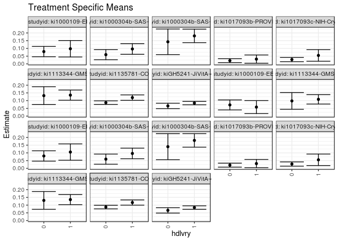

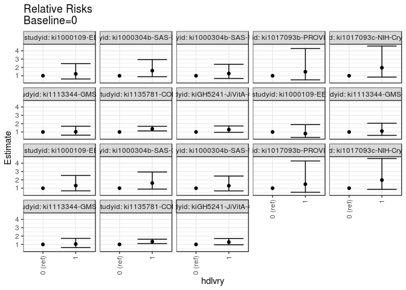

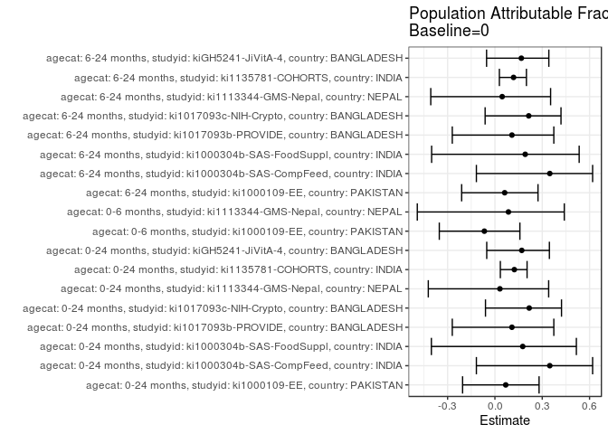

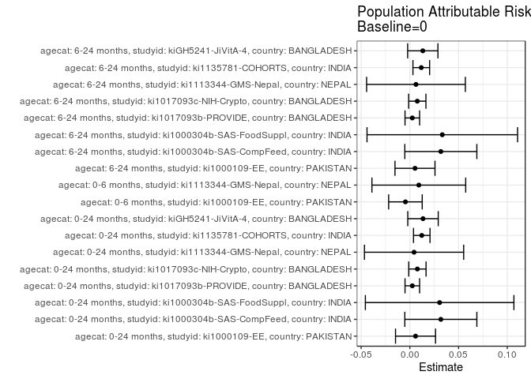

## Results Table

### Parameter: TSM

| agecat | studyid | country | intervention_level | baseline_level | estimate | ci_lower | ci_upper |
| --- | --- | --- | --- | --- | --- | --- | --- |
| 0-24 months | ki1000109-EE | PAKISTAN | 0 | NA | 0.0794890 | 0.0460255 | 0.1129525 |
| 0-24 months | ki1000109-EE | PAKISTAN | 1 | NA | 0.0977956 | 0.0446096 | 0.1509816 |
| 0-24 months | ki1000304b-SAS-CompFeed | INDIA | 0 | NA | 0.0596026 | 0.0268592 | 0.0923461 |
| 0-24 months | ki1000304b-SAS-CompFeed | INDIA | 1 | NA | 0.0963731 | 0.0619791 | 0.1307670 |
| 0-24 months | ki1000304b-SAS-FoodSuppl | INDIA | 0 | NA | 0.1427651 | 0.0599573 | 0.2255730 |
| 0-24 months | ki1000304b-SAS-FoodSuppl | INDIA | 1 | NA | 0.1809100 | 0.1372086 | 0.2246113 |
| 0-24 months | ki1017093b-PROVIDE | BANGLADESH | 0 | NA | 0.0208768 | 0.0080633 | 0.0336904 |
| 0-24 months | ki1017093b-PROVIDE | BANGLADESH | 1 | NA | 0.0308642 | 0.0042110 | 0.0575174 |
| 0-24 months | ki1017093c-NIH-Crypto | BANGLADESH | 0 | NA | 0.0278720 | 0.0142032 | 0.0415407 |
| 0-24 months | ki1017093c-NIH-Crypto | BANGLADESH | 1 | NA | 0.0546116 | 0.0170419 | 0.0921813 |
| 0-24 months | ki1113344-GMS-Nepal | NEPAL | 0 | NA | 0.1323688 | 0.0746529 | 0.1900846 |
| 0-24 months | ki1113344-GMS-Nepal | NEPAL | 1 | NA | 0.1356291 | 0.1028607 | 0.1683975 |
| 0-24 months | ki1135781-COHORTS | INDIA | 0 | NA | 0.0869886 | 0.0752252 | 0.0987521 |
| 0-24 months | ki1135781-COHORTS | INDIA | 1 | NA | 0.1197203 | 0.1024147 | 0.1370259 |
| 0-24 months | kiGH5241-JiVitA-4 | BANGLADESH | 0 | NA | 0.0658075 | 0.0481887 | 0.0834264 |
| 0-24 months | kiGH5241-JiVitA-4 | BANGLADESH | 1 | NA | 0.0843184 | 0.0732361 | 0.0954006 |
| 0-6 months | ki1000109-EE | PAKISTAN | 0 | NA | 0.0722892 | 0.0400799 | 0.1044984 |
| 0-6 months | ki1000109-EE | PAKISTAN | 1 | NA | 0.0583333 | 0.0163426 | 0.1003241 |
| 0-6 months | ki1113344-GMS-Nepal | NEPAL | 0 | NA | 0.0981454 | 0.0442345 | 0.1520563 |
| 0-6 months | ki1113344-GMS-Nepal | NEPAL | 1 | NA | 0.1084812 | 0.0780566 | 0.1389059 |
| 6-24 months | ki1000109-EE | PAKISTAN | 0 | NA | 0.0800544 | 0.0467519 | 0.1133570 |
| 6-24 months | ki1000109-EE | PAKISTAN | 1 | NA | 0.1053512 | 0.0525798 | 0.1581226 |
| 6-24 months | ki1000304b-SAS-CompFeed | INDIA | 0 | NA | 0.0596026 | 0.0268592 | 0.0923461 |
| 6-24 months | ki1000304b-SAS-CompFeed | INDIA | 1 | NA | 0.0963731 | 0.0619791 | 0.1307670 |
| 6-24 months | ki1000304b-SAS-FoodSuppl | INDIA | 0 | NA | 0.1400427 | 0.0560847 | 0.2240008 |
| 6-24 months | ki1000304b-SAS-FoodSuppl | INDIA | 1 | NA | 0.1805551 | 0.1370325 | 0.2240778 |
| 6-24 months | ki1017093b-PROVIDE | BANGLADESH | 0 | NA | 0.0208768 | 0.0080633 | 0.0336904 |
| 6-24 months | ki1017093b-PROVIDE | BANGLADESH | 1 | NA | 0.0308642 | 0.0042110 | 0.0575174 |
| 6-24 months | ki1017093c-NIH-Crypto | BANGLADESH | 0 | NA | 0.0279800 | 0.0143152 | 0.0416449 |
| 6-24 months | ki1017093c-NIH-Crypto | BANGLADESH | 1 | NA | 0.0552684 | 0.0178660 | 0.0926707 |
| 6-24 months | ki1113344-GMS-Nepal | NEPAL | 0 | NA | 0.1304010 | 0.0730604 | 0.1877416 |
| 6-24 months | ki1113344-GMS-Nepal | NEPAL | 1 | NA | 0.1356530 | 0.1029142 | 0.1683917 |
| 6-24 months | ki1135781-COHORTS | INDIA | 0 | NA | 0.0874887 | 0.0756157 | 0.0993616 |
| 6-24 months | ki1135781-COHORTS | INDIA | 1 | NA | 0.1166278 | 0.0999609 | 0.1332946 |
| 6-24 months | kiGH5241-JiVitA-4 | BANGLADESH | 0 | NA | 0.0660179 | 0.0485160 | 0.0835198 |
| 6-24 months | kiGH5241-JiVitA-4 | BANGLADESH | 1 | NA | 0.0842922 | 0.0731945 | 0.0953898 |

### Parameter: E(Y)

| agecat | studyid | country | intervention_level | baseline_level | estimate | ci_lower | ci_upper |
| --- | --- | --- | --- | --- | --- | --- | --- |
| 0-24 months | ki1000109-EE | PAKISTAN | NA | NA | 0.0853333 | 0.0570192 | 0.1136475 |
| 0-24 months | ki1000304b-SAS-CompFeed | INDIA | NA | NA | 0.0913978 | 0.0593363 | 0.1234594 |
| 0-24 months | ki1000304b-SAS-FoodSuppl | INDIA | NA | NA | 0.1733333 | 0.1349698 | 0.2116969 |
| 0-24 months | ki1017093b-PROVIDE | BANGLADESH | NA | NA | 0.0234009 | 0.0116889 | 0.0351130 |
| 0-24 months | ki1017093c-NIH-Crypto | BANGLADESH | NA | NA | 0.0356164 | 0.0221630 | 0.0490699 |
| 0-24 months | ki1113344-GMS-Nepal | NEPAL | NA | NA | 0.1366906 | 0.1081112 | 0.1652701 |
| 0-24 months | ki1135781-COHORTS | INDIA | NA | NA | 0.0992114 | 0.0898650 | 0.1085578 |
| 0-24 months | kiGH5241-JiVitA-4 | BANGLADESH | NA | NA | 0.0793041 | 0.0701363 | 0.0884719 |
| 0-6 months | ki1000109-EE | PAKISTAN | NA | NA | 0.0677507 | 0.0420735 | 0.0934278 |
| 0-6 months | ki1113344-GMS-Nepal | NEPAL | NA | NA | 0.1073446 | 0.0809909 | 0.1336984 |
| 6-24 months | ki1000109-EE | PAKISTAN | NA | NA | 0.0853333 | 0.0570192 | 0.1136475 |
| 6-24 months | ki1000304b-SAS-CompFeed | INDIA | NA | NA | 0.0913978 | 0.0593363 | 0.1234594 |
| 6-24 months | ki1000304b-SAS-FoodSuppl | INDIA | NA | NA | 0.1733333 | 0.1349698 | 0.2116969 |
| 6-24 months | ki1017093b-PROVIDE | BANGLADESH | NA | NA | 0.0234009 | 0.0116889 | 0.0351130 |
| 6-24 months | ki1017093c-NIH-Crypto | BANGLADESH | NA | NA | 0.0356164 | 0.0221630 | 0.0490699 |
| 6-24 months | ki1113344-GMS-Nepal | NEPAL | NA | NA | 0.1366906 | 0.1081112 | 0.1652701 |
| 6-24 months | ki1135781-COHORTS | INDIA | NA | NA | 0.0992114 | 0.0898650 | 0.1085578 |
| 6-24 months | kiGH5241-JiVitA-4 | BANGLADESH | NA | NA | 0.0793041 | 0.0701363 | 0.0884719 |

### Parameter: RR

| agecat | studyid | country | intervention_level | baseline_level | estimate | ci_lower | ci_upper |
| --- | --- | --- | --- | --- | --- | --- | --- |
| 0-24 months | ki1000109-EE | PAKISTAN | 0 | 0 | 1.0000000 | 1.0000000 | 1.000000 |
| 0-24 months | ki1000109-EE | PAKISTAN | 1 | 0 | 1.2303034 | 0.6175434 | 2.451077 |
| 0-24 months | ki1000304b-SAS-CompFeed | INDIA | 0 | 0 | 1.0000000 | 1.0000000 | 1.000000 |
| 0-24 months | ki1000304b-SAS-CompFeed | INDIA | 1 | 0 | 1.6169257 | 0.8882404 | 2.943402 |
| 0-24 months | ki1000304b-SAS-FoodSuppl | INDIA | 0 | 0 | 1.0000000 | 1.0000000 | 1.000000 |
| 0-24 months | ki1000304b-SAS-FoodSuppl | INDIA | 1 | 0 | 1.2671857 | 0.6768315 | 2.372466 |
| 0-24 months | ki1017093b-PROVIDE | BANGLADESH | 0 | 0 | 1.0000000 | 1.0000000 | 1.000000 |
| 0-24 months | ki1017093b-PROVIDE | BANGLADESH | 1 | 0 | 1.4783951 | 0.5124750 | 4.264894 |
| 0-24 months | ki1017093c-NIH-Crypto | BANGLADESH | 0 | 0 | 1.0000000 | 1.0000000 | 1.000000 |
| 0-24 months | ki1017093c-NIH-Crypto | BANGLADESH | 1 | 0 | 1.9593738 | 0.8412013 | 4.563885 |
| 0-24 months | ki1113344-GMS-Nepal | NEPAL | 0 | 0 | 1.0000000 | 1.0000000 | 1.000000 |
| 0-24 months | ki1113344-GMS-Nepal | NEPAL | 1 | 0 | 1.0246311 | 0.6214654 | 1.689344 |
| 0-24 months | ki1135781-COHORTS | INDIA | 0 | 0 | 1.0000000 | 1.0000000 | 1.000000 |
| 0-24 months | ki1135781-COHORTS | INDIA | 1 | 0 | 1.3762751 | 1.1293802 | 1.677144 |
| 0-24 months | kiGH5241-JiVitA-4 | BANGLADESH | 0 | 0 | 1.0000000 | 1.0000000 | 1.000000 |
| 0-24 months | kiGH5241-JiVitA-4 | BANGLADESH | 1 | 0 | 1.2812872 | 0.9531738 | 1.722348 |
| 0-6 months | ki1000109-EE | PAKISTAN | 0 | 0 | 1.0000000 | 1.0000000 | 1.000000 |
| 0-6 months | ki1000109-EE | PAKISTAN | 1 | 0 | 0.8069444 | 0.3460819 | 1.881518 |
| 0-6 months | ki1113344-GMS-Nepal | NEPAL | 0 | 0 | 1.0000000 | 1.0000000 | 1.000000 |
| 0-6 months | ki1113344-GMS-Nepal | NEPAL | 1 | 0 | 1.1053113 | 0.5961628 | 2.049294 |
| 6-24 months | ki1000109-EE | PAKISTAN | 0 | 0 | 1.0000000 | 1.0000000 | 1.000000 |
| 6-24 months | ki1000109-EE | PAKISTAN | 1 | 0 | 1.3159947 | 0.6857872 | 2.525335 |
| 6-24 months | ki1000304b-SAS-CompFeed | INDIA | 0 | 0 | 1.0000000 | 1.0000000 | 1.000000 |
| 6-24 months | ki1000304b-SAS-CompFeed | INDIA | 1 | 0 | 1.6169257 | 0.8882404 | 2.943402 |
| 6-24 months | ki1000304b-SAS-FoodSuppl | INDIA | 0 | 0 | 1.0000000 | 1.0000000 | 1.000000 |
| 6-24 months | ki1000304b-SAS-FoodSuppl | INDIA | 1 | 0 | 1.2892861 | 0.6770015 | 2.455325 |
| 6-24 months | ki1017093b-PROVIDE | BANGLADESH | 0 | 0 | 1.0000000 | 1.0000000 | 1.000000 |
| 6-24 months | ki1017093b-PROVIDE | BANGLADESH | 1 | 0 | 1.4783951 | 0.5124750 | 4.264894 |
| 6-24 months | ki1017093c-NIH-Crypto | BANGLADESH | 0 | 0 | 1.0000000 | 1.0000000 | 1.000000 |
| 6-24 months | ki1017093c-NIH-Crypto | BANGLADESH | 1 | 0 | 1.9752808 | 0.8570674 | 4.552424 |
| 6-24 months | ki1113344-GMS-Nepal | NEPAL | 0 | 0 | 1.0000000 | 1.0000000 | 1.000000 |
| 6-24 months | ki1113344-GMS-Nepal | NEPAL | 1 | 0 | 1.0402755 | 0.6287250 | 1.721219 |
| 6-24 months | ki1135781-COHORTS | INDIA | 0 | 0 | 1.0000000 | 1.0000000 | 1.000000 |
| 6-24 months | ki1135781-COHORTS | INDIA | 1 | 0 | 1.3330614 | 1.0949936 | 1.622889 |
| 6-24 months | kiGH5241-JiVitA-4 | BANGLADESH | 0 | 0 | 1.0000000 | 1.0000000 | 1.000000 |
| 6-24 months | kiGH5241-JiVitA-4 | BANGLADESH | 1 | 0 | 1.2768085 | 0.9519026 | 1.712612 |

### Parameter: PAR

| agecat | studyid | country | intervention_level | baseline_level | estimate | ci_lower | ci_upper |
| --- | --- | --- | --- | --- | --- | --- | --- |
| 0-24 months | ki1000109-EE | PAKISTAN | 0 | NA | 0.0058443 | -0.0146997 | 0.0263883 |
| 0-24 months | ki1000304b-SAS-CompFeed | INDIA | 0 | NA | 0.0317952 | -0.0051651 | 0.0687555 |
| 0-24 months | ki1000304b-SAS-FoodSuppl | INDIA | 0 | NA | 0.0305682 | -0.0456484 | 0.1067848 |
| 0-24 months | ki1017093b-PROVIDE | BANGLADESH | 0 | NA | 0.0025241 | -0.0049575 | 0.0100057 |
| 0-24 months | ki1017093c-NIH-Crypto | BANGLADESH | 0 | NA | 0.0077445 | -0.0011302 | 0.0166191 |
| 0-24 months | ki1113344-GMS-Nepal | NEPAL | 0 | NA | 0.0043219 | -0.0465914 | 0.0552352 |
| 0-24 months | ki1135781-COHORTS | INDIA | 0 | NA | 0.0122227 | 0.0037591 | 0.0206864 |
| 0-24 months | kiGH5241-JiVitA-4 | BANGLADESH | 0 | NA | 0.0134966 | -0.0021253 | 0.0291185 |
| 0-6 months | ki1000109-EE | PAKISTAN | 0 | NA | -0.0045385 | -0.0217616 | 0.0126846 |
| 0-6 months | ki1113344-GMS-Nepal | NEPAL | 0 | NA | 0.0091992 | -0.0389130 | 0.0573115 |
| 6-24 months | ki1000109-EE | PAKISTAN | 0 | NA | 0.0052789 | -0.0152499 | 0.0258077 |
| 6-24 months | ki1000304b-SAS-CompFeed | INDIA | 0 | NA | 0.0317952 | -0.0051651 | 0.0687555 |
| 6-24 months | ki1000304b-SAS-FoodSuppl | INDIA | 0 | NA | 0.0332906 | -0.0439583 | 0.1105395 |
| 6-24 months | ki1017093b-PROVIDE | BANGLADESH | 0 | NA | 0.0025241 | -0.0049575 | 0.0100057 |
| 6-24 months | ki1017093c-NIH-Crypto | BANGLADESH | 0 | NA | 0.0076364 | -0.0012228 | 0.0164956 |
| 6-24 months | ki1113344-GMS-Nepal | NEPAL | 0 | NA | 0.0062896 | -0.0443808 | 0.0569601 |
| 6-24 months | ki1135781-COHORTS | INDIA | 0 | NA | 0.0117227 | 0.0031658 | 0.0202796 |
| 6-24 months | kiGH5241-JiVitA-4 | BANGLADESH | 0 | NA | 0.0132862 | -0.0022502 | 0.0288227 |

### Parameter: PAF

| agecat | studyid | country | intervention_level | baseline_level | estimate | ci_lower | ci_upper |
| --- | --- | --- | --- | --- | --- | --- | --- |
| 0-24 months | ki1000109-EE | PAKISTAN | 0 | NA | 0.0684878 | -0.2049936 | 0.2799007 |
| 0-24 months | ki1000304b-SAS-CompFeed | INDIA | 0 | NA | 0.3478769 | -0.1175046 | 0.6194516 |
| 0-24 months | ki1000304b-SAS-FoodSuppl | INDIA | 0 | NA | 0.1763550 | -0.4028607 | 0.5164230 |
| 0-24 months | ki1017093b-PROVIDE | BANGLADESH | 0 | NA | 0.1078636 | -0.2703716 | 0.3734846 |
| 0-24 months | ki1017093c-NIH-Crypto | BANGLADESH | 0 | NA | 0.2174410 | -0.0598317 | 0.4221738 |
| 0-24 months | ki1113344-GMS-Nepal | NEPAL | 0 | NA | 0.0316181 | -0.4224514 | 0.3407412 |
| 0-24 months | ki1135781-COHORTS | INDIA | 0 | NA | 0.1231990 | 0.0344012 | 0.2038309 |
| 0-24 months | kiGH5241-JiVitA-4 | BANGLADESH | 0 | NA | 0.1701875 | -0.0518530 | 0.3453565 |
| 0-6 months | ki1000109-EE | PAKISTAN | 0 | NA | -0.0669880 | -0.3526787 | 0.1583639 |
| 0-6 months | ki1113344-GMS-Nepal | NEPAL | 0 | NA | 0.0856981 | -0.4921613 | 0.4397738 |
| 6-24 months | ki1000109-EE | PAKISTAN | 0 | NA | 0.0618623 | -0.2108958 | 0.2731807 |
| 6-24 months | ki1000304b-SAS-CompFeed | INDIA | 0 | NA | 0.3478769 | -0.1175046 | 0.6194516 |
| 6-24 months | ki1000304b-SAS-FoodSuppl | INDIA | 0 | NA | 0.1920612 | -0.4012790 | 0.5341648 |
| 6-24 months | ki1017093b-PROVIDE | BANGLADESH | 0 | NA | 0.1078636 | -0.2703716 | 0.3734846 |
| 6-24 months | ki1017093c-NIH-Crypto | BANGLADESH | 0 | NA | 0.2144072 | -0.0621250 | 0.4189422 |
| 6-24 months | ki1113344-GMS-Nepal | NEPAL | 0 | NA | 0.0460137 | -0.4067238 | 0.3530430 |
| 6-24 months | ki1135781-COHORTS | INDIA | 0 | NA | 0.1181592 | 0.0282662 | 0.1997363 |
| 6-24 months | kiGH5241-JiVitA-4 | BANGLADESH | 0 | NA | 0.1675354 | -0.0529132 | 0.3418287 |